> **Submission.** Knit your Rmd file into HTML and submit it via Brightspace. Include a link to your git repository (GitHub or git.cs.dal.ca) as a comment on your submission.

## 0 Setup

```r
library(tidyverse)    # dplyr, ggplot2, tidyr, purrr, ...
library(tidymodels)   # rsample, recipes, parsnip, workflows, tune, yardstick, ...
library(ranger)       # random forest engine
library(xgboost)      # gradient-boosted trees engine
library(glmnet)       # penalised logistic regression engine
library(here)
library(fs)

theme_set(theme_minimal(base_size = 11) +
  theme(panel.grid.minor = element_blank()))
```

## 1 Introduction

[Sepsis](https://www.who.int/news-room/fact-sheets/detail/sepsis) is life-threatening organ dysfunction caused by a dysregulated immune response to infection. It accounts for roughly 20 % of global deaths, and each hour of delayed treatment increases mortality by 4–8 %.

The [PhysioNet/CinC Challenge 2019](https://physionet.org/content/challenge-2019/1.0.0/) dataset contains hourly ICU records for ~40 000 patients from two US teaching hospitals. Each record (row) has 8 vital signs, 26 laboratory measurements, 6 demographic fields, and a binary `SepsisLabel` (set to 1 up to 6 hours *before* clinical onset so that early-warning models can be trained). We simplify the temporal problem to a static one by taking one random hourly record per patient, giving a standard tabular classification task with realistic clinical challenges: class imbalance, high missingness, and mixed data types.

**Q1. (2 marks)** Look up the [PhysioNet variable descriptions](https://physionet.org/content/challenge-2019/1.0.0/) and include an explanation of the dataset into this notebook (one row per variable: name, description, units).

->Vital Signs Variable

| Variable Name | Description | Unit |
| --- | --- | --- |
| HR | Heart rate of a patient | beats per minute |
| O2Sat | Pulse Oximetry | % |
| Temp | Temperature of patient body | Deg C |
| SBP | Systolic BP | mm Hg |
| MAP | Mean arterial pressure | mm Hg |
| DBP | Diastolic BP | mm Hg |
| Resp | Respiration rate | breaths per minute |
| EtCO2 | End tidal carbon dioxide | mm Hg |

->Laboratory Values

| Variable name | Description | Unit |
| --- | --- | --- |
| BaseExcess | Measure of excess bicarbonate | mmol/L |
| HCO3 | Bicarbonate | mmol/L |
| FiO2 | Fraction of inspired oxygen | % |
| pH | N/A | N/A |
| PaCO2 | Partial pressure of carbon dioxide from arterial blood | mm Hg |
| SaO2 | Oxygen saturation from arterial blood | % |
| AST | Aspartate transaminase | IU/L |
| BUN | Blood urea nitrogen | mg/dL |
| Alkalinephos | Alkaline phosphatase | IU/L |
| Calcium | Mineral | mg/dL |
| Chloride | Mineral | mmol/L |
| Creatinine | Oraganic Waste | mg/dL |
| Bilirubin_direct | Bilirubin direct | mg/dL |
| Glucose | Serum glucose | mg/dL |
| Lactate | Lactic acid | mg/dL |
| Magnesium | Mineral | mmol/dL |
| Phosphate | Mineral | mg/dL |
| Potassium | Mineral | mmol/L |
| Bilirubin_total | Total bilirubin | mg/dL |
| TroponinI | Troponin I | ng/mL |
| Hct | Hematocrit | % |
| Hgb | Hemoglobin | g/dL |
| PTT | partial thromboplastin time | seconds |
| WBC | Leukocyte count | count*10^3/µL |
| Fibrinogen | Protein | mg/dL |
| Platelets | Cell | count*10^3/µL |

-> Demographics

| Variable Name | Description | Unit |
| --- | --- | --- |
| Age | Years (100 for patients 90 or above) | Year |
| Gender | Female or Male | Binary Number (0) or (1) |
| Unit1 | Administrative identifier for ICU unit | MICU |
| Unit2 | Administrative identifier for ICU unit | SICU |
| HospAdmTime | Hours between hospital admit and ICU admit | Hour |
| ICULOS | ICU length-of-stay (hours since ICU admit) | Hour |

**Q2. (2 marks)** Then choose **three variables** you hypothesise might be strong predictors of sepsis and write one sentence each explaining your reasoning. There is no right or wrong answer to this, but you should think about your and problem before diving into the EDA and prediction! *(Hint: look up how sepsis is clinically diagnosed.)*

**1) Temperature (c):** Change in body temperature tells if infection is casuing a severe fever or abnormally low body temperature (hypothermia), making temperature changes an immediate indicator of a potential infection source.

**2) Mean arterial pressure (mm Hg):** Sepsis-3 relies on the SOFA score to identify organ failure ($t_{\text{SOFA}}$), and a severe drop in MAP indicates cardiovascular dysfunction, where the body’s blood pressure falls dangerously low due to systemic infection.

**3) Creatinine :** Sharp increase in creatinine levels acts as a direct laboratory indicator of sepsis. It depicts Kidney dysfunction.

## 2 Data Loading and Splitting

To avoid inadvertent data leakage from your test set, we are going to perform our test-train split before even our EDA and cleaning related analyses. This is not always done but is a good practice if you aren’t using an external/independent test dataset.

### 2.1 Load the data

I’ve already done the random sampling of the dataset to remove the time-series elements but the original dataset can be acquired directly from [PhysioNet/CinC Challenge 2019](https://physionet.org/content/challenge-2019/1.0.0/)

```r
data_dir  <- here("data")
cache_dir <- fs::path(data_dir, "cache")
fs::dir_create(cache_dir)

data_url <- "http://maguire-lab.github.io/health_data_science_research_2026/static_files/practicals/lab1_data/physionet_subsample_modified_1.0.0.rds"
rds_path <- fs::path(cache_dir, "physionet_subsample_1.0.0.rds")
```

Rmd lets you cache expensive or slow operations (like downloading big files or complicated processing) so they only re-run if the code and variables have changed. This can be very useful although can sometimes cause some inadvertent issues that reduce reproducibility! You should also do a completely clean re-run of everything once your analyses are finalised if possible.

```r
if (!file.exists(rds_path)) {
  download.file(data_url, rds_path, mode = "wb", quiet = TRUE)
}
sepsis <- readRDS(rds_path)
```

### 2.2 Train / test split

We split the data **before** any exploration so that analysis choices cannot be influenced by the test set - this is a key discipline in applied machine learning. Stratified splitting preserves the sepsis rate in both halves.

```r
# will make later things easier to do!s
sepsis <- sepsis |>
  mutate(SepsisLabel = factor(SepsisLabel,
                              levels = c(1, 0),
                              labels = c("Sepsis", "No Sepsis")))

# splitting
split <- initial_split(sepsis, prop = 0.75, strata = SepsisLabel)
train <- training(split)
test  <- testing(split)

cat("Training rows:", nrow(train), "\n")
```

```
## Training rows: 2250
```

```r
cat("Test rows:    ", nrow(test),  "\n")
```

```
## Test rows:     750
```

**Q3. (1 mark)** What percentage of our dataset is being assigned to test? - 25% of the datasets goes fro testing.

## 3 Exploratory Data Analysis

Again, do your EDA on `train` only - we do not look at `test` until Section 6.

### 3.1 Class balance

**Q4. (2 marks).** Uncomment and csomplete the code below to check the class balance in the **training** set. `count()` tallies rows per group; add a `prop` column to show each class as a fraction of the total.

```r
train |>
  count(SepsisLabel) |>
  mutate(prop = n / sum(n))
```

```
##   SepsisLabel    n  prop
## 1      Sepsis   72 0.032
## 2   No Sepsis 2178 0.968
```

**Q5. (2 mark)** Using your solution to Q4, complete this plotting code to create a barplot of the relative sepsis label balance. Change the colour of the sepsis bar to green.

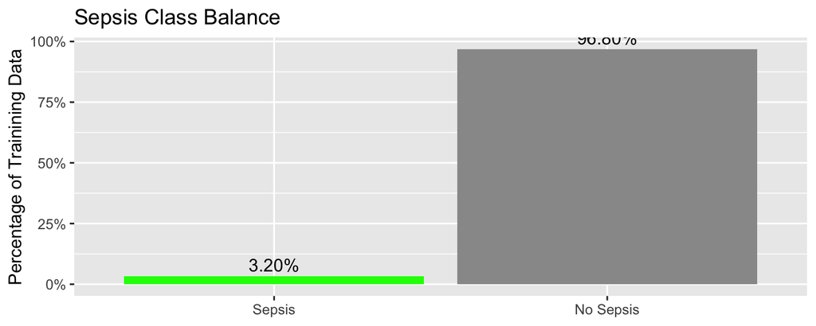

```r
#code from your answer to Q3,
train |>
  count(SepsisLabel) |>
  mutate(prop = n / sum(n)) |>
  ggplot(aes(SepsisLabel, prop, fill = SepsisLabel)) +
  geom_col() +
  geom_text(aes(label = scales::percent(prop, accuracy = 0.01)), vjust = -0.4) +
  scale_y_continuous(labels = scales::percent) +
  scale_fill_manual(values = c("No Sepsis" = "grey60",
                               "Sepsis"    = "green")) +
  labs(x = NULL, y = "Percentage of Trainining Data", title = "Sepsis Class Balance") +
  theme(legend.position = "none")
```

**Q6. (3 marks)** Given the class imbalance, which of the following 2 metrics might be the most misleading and why? accuracy, precision, recall, F1-score, ROC-AUC, PR-AUC?

1. Accuracy is most misleading because it can be artificially inflated when the majority class dominates. For example, in a highly imbalanced dataset, a model that always predicts the majority class can achieve high accuracy while performing poorly on the minority class. This makes accuracy an unreliable metric for evaluating model performance in such scenarios.
2. ROC-AUC is most misleading because it can be misleading in imbalanced datasets when the positive class is rare. ROC-AUC measures the area under the ROC curve, which is based on the true positive rate and false positive rate. However, in highly imbalanced datasets, the true positive rate can be artificially high due to the large number of negative examples, leading to an overestimation of the model’s performance. Additionally, ROC-AUC does not account for class imbalance directly, making it less informative in such scenarios.

### 3.2 Missingness

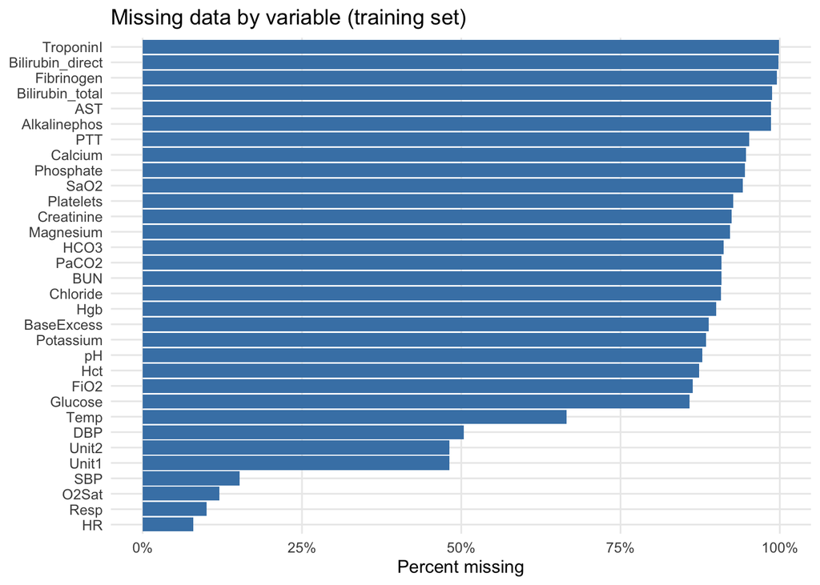

```r
train |>
  summarise(across(everything(), ~ mean(is.na(.x)))) |>
  pivot_longer(everything(),
               names_to = "variable", values_to = "pct_missing") |>
  filter(pct_missing > 0) |>
  ggplot(aes(pct_missing, fct_reorder(variable, pct_missing))) +
  geom_col(fill = "steelblue") +
  scale_x_continuous(labels = scales::percent_format(accuracy = 1)) +
  labs(title = "Missing data by variable (training set)",
       x = "Percent missing", y = NULL)
```

**Q7. (1 mark)** Modify the above to plot only missingness for Sepsis positive data

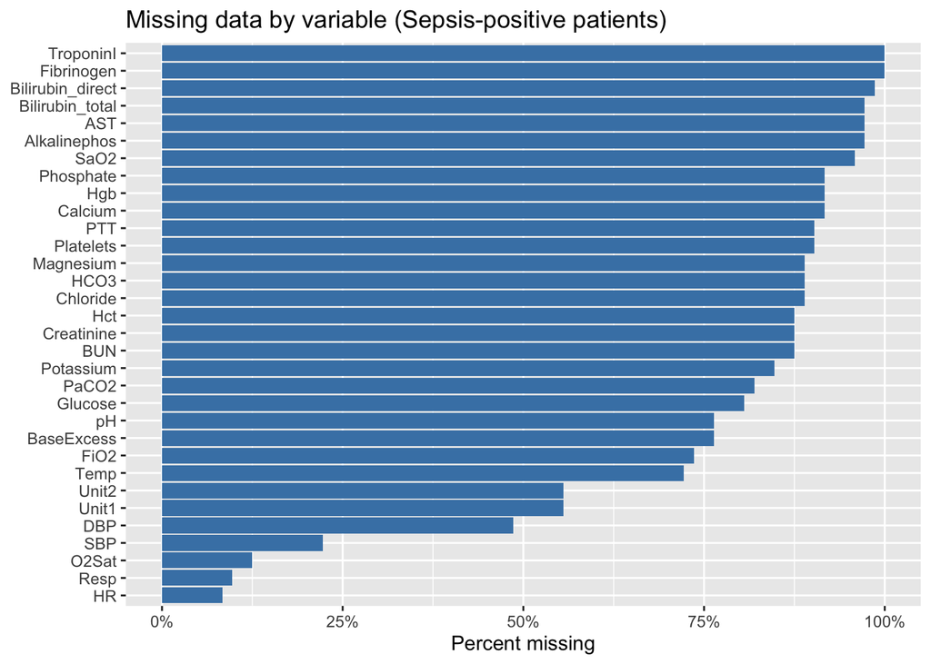

```r
# add your code
train |>
  filter(SepsisLabel == "Sepsis") |>
  summarise(across(everything(), ~ mean(is.na(.x)))) |>
  pivot_longer(everything(),
               names_to = "variable", values_to = "pct_missing") |>
  filter(pct_missing > 0) |>
  ggplot(aes(pct_missing, fct_reorder(variable, pct_missing))) +
  geom_col(fill = "steelblue") +
  scale_x_continuous(labels = scales::percent_format(accuracy = 1)) +
  labs(title = "Missing data by variable (Sepsis-positive patients)",
       x = "Percent missing", y = NULL)
```

**Q8. (3 marks)** Which three variables have the highest missingness? In an ICU context, why might a lab value be missing - is this likely to be random, or informative? Does this mean you should drop or impute these values?

- The three variables with highest missingness are Troponini, Bilirubin_direct , and Fibrinogen.

Those three variable are the highest missing Lab values because those three typically only ordered when a clinician suspects a specific condition. A missing value therefore doesn’t mean the data is lost it likely means the test wasn’t clinically indicated. This is not random it’s informative missingness.

Never blindly drop values but with almost 99% missingness, these columns carry almost no information in the traditional sense. However, since missingness itself is informative (a missing Troponin likely means “no cardiac concern”).We should Impute to retain the signal that the test was not ordered and Drop only if you believe the variable adds no predictive value even as a missingness indicator.

For a model, imputing with median + adding a binary missingness indicator column is generally the safest approach. It preserves the informative signal without letting the high missingness break model.

### 3.3 Vital-sign distributions by outcome

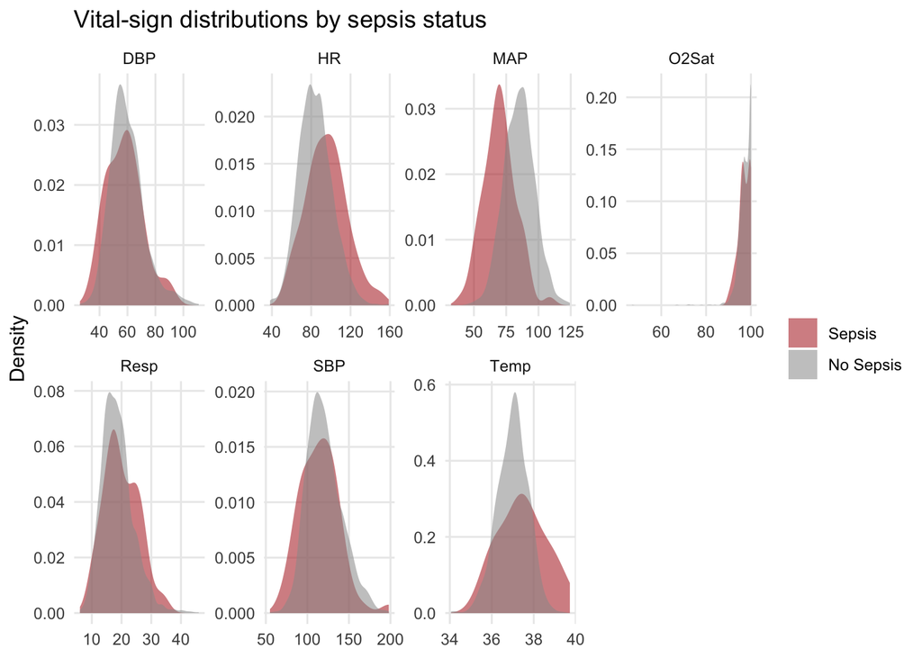

```r
vitals <- c("HR", "O2Sat", "Temp", "SBP", "MAP", "DBP", "Resp")

train |>
  select(all_of(vitals), SepsisLabel) |>
  pivot_longer(-SepsisLabel) |>
  filter(!is.na(value)) |>
  ggplot(aes(value, fill = SepsisLabel)) +
  geom_density(alpha = 0.55, colour = NA) +
  facet_wrap(~ name, scales = "free", ncol = 4) +
  scale_fill_manual(values = c("No Sepsis" = "grey60",
                               "Sepsis"    = "firebrick")) +
  labs(x = NULL, y = "Density", fill = NULL,
       title = "Vital-sign distributions by sepsis status")
```

**Q9 (2 marks).** Modify the code above to plot the distribution of **three other lab variables** of your choice.

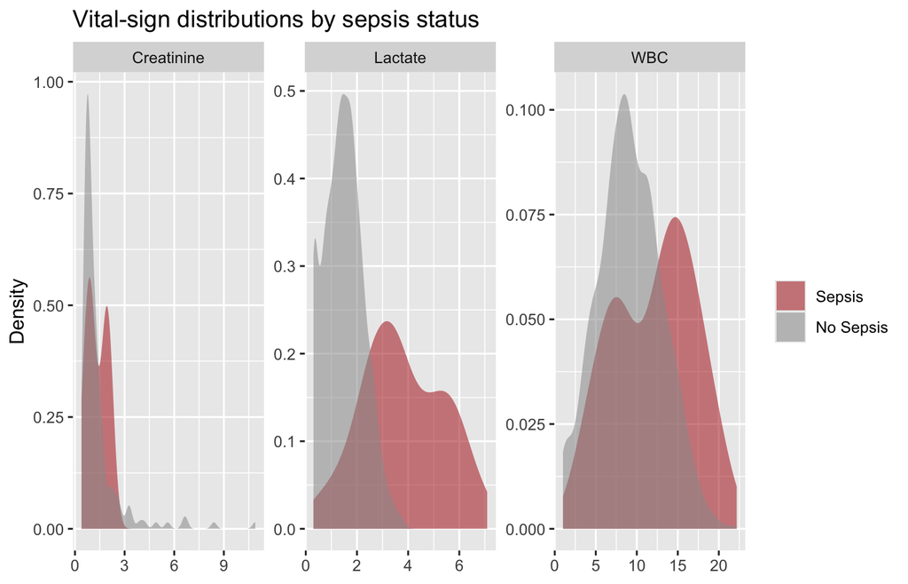

```r
vitals <- c("Creatinine", "Lactate", "WBC")

train |>
  select(all_of(vitals), SepsisLabel) |>
  pivot_longer(-SepsisLabel) |>
  filter(!is.na(value)) |>
  ggplot(aes(value, fill = SepsisLabel)) +
  geom_density(alpha = 0.55, colour = NA) +
  facet_wrap(~ name, scales = "free", ncol = 4) +
  scale_fill_manual(values = c("No Sepsis" = "grey60",
                               "Sepsis"    = "firebrick")) +
  labs(x = NULL, y = "Density", fill = NULL,
       title = "Vital-sign distributions by sepsis status")
```

Correlation plot of all variables by similarity of their correlation in Sepsis and Non-Sepsis

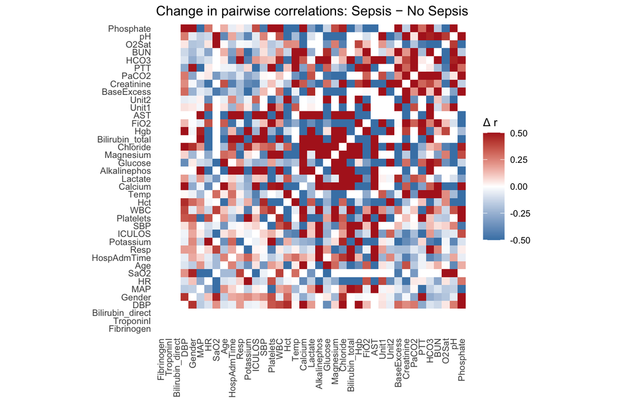

```r
cor_mat <- function(df) {
  df |>
    select(where(is.numeric)) |>
    cor(use = "pairwise.complete.obs")
}

m_ns  <- cor_mat(train |> filter(SepsisLabel == "No Sepsis"))
m_sep <- cor_mat(train |> filter(SepsisLabel == "Sepsis"))
m_dif <- m_sep - m_ns

m_dif[is.na(m_dif)] <- 0
hc <- hclust(as.dist(1 - abs(m_dif)), method = "average")
var_order <- hc$labels[hc$order]

m_dif |>
  as.data.frame() |>
  tibble::rownames_to_column("var1") |>
  tidyr::pivot_longer(-var1, names_to = "var2", values_to = "diff") |>
  mutate(var1 = factor(var1, levels = var_order),
         var2 = factor(var2, levels = var_order)) |>
  ggplot(aes(var1, var2, fill = diff)) +
  geom_tile() +
  scale_fill_gradient2(low = "steelblue", mid = "white", high = "firebrick",
                       midpoint = 0, limits = c(-0.5, 0.5),
                       oob = scales::squish, name = "Δ r") +
  coord_fixed() +
  labs(x = NULL, y = NULL,
       title = "Change in pairwise correlations: Sepsis − No Sepsis") +
  theme_minimal(base_size = 9) +
  theme(axis.text.x = element_text(angle = 90, hjust = 1, vjust = 0.5),
        panel.grid  = element_blank())
```

### 3.4 Dimensionality reduction

PCA compresses all numeric features into a small number of axes and lets us ask: *do septic and non-septic patients separate at all in the joint feature space?* We build it inside a small `recipe` so the preprocessing (imputation, normalisation) is explicit and reproducible.

Recipes are a special type of function in `tidymodels` that differ from normal R functions in key ways (internal state).

A plain R function executes immediately and is stateless i.e., every call recomputes from scratch.

```
rscale_hr <- function(x) (x - mean(x, na.rm = TRUE)) / sd(x, na.rm = TRUE)

train$HR_z <- scale_hr(train$HR)
test$HR_z  <- scale_hr(test$HR)   # BUG: uses test set's own mean/sd
```

A recipe on the otherhand is a two-phase object: first you declare the steps, then you `prep()` it on training data (which estimates and stores any required parameters means, sds, imputation values, factor levels, PCA loadings…), then you `bake()` it on any new data to apply the same learned transformations.

```r
pca_prep <- recipe(SepsisLabel ~ ., data = train) |>
  step_rm(ICULOS, HospAdmTime) |>
  step_impute_median(all_numeric_predictors()) |>
  step_impute_mode(all_nominal_predictors()) |>
  step_dummy(all_nominal_predictors(), one_hot = FALSE) |>
  step_zv(all_predictors()) |>
  step_normalize(all_numeric_predictors()) |>
  step_pca(all_numeric_predictors(), num_comp = 10, id = "pca") |>
  prep()

pca_scores <- bake(pca_prep, new_data = NULL)
```

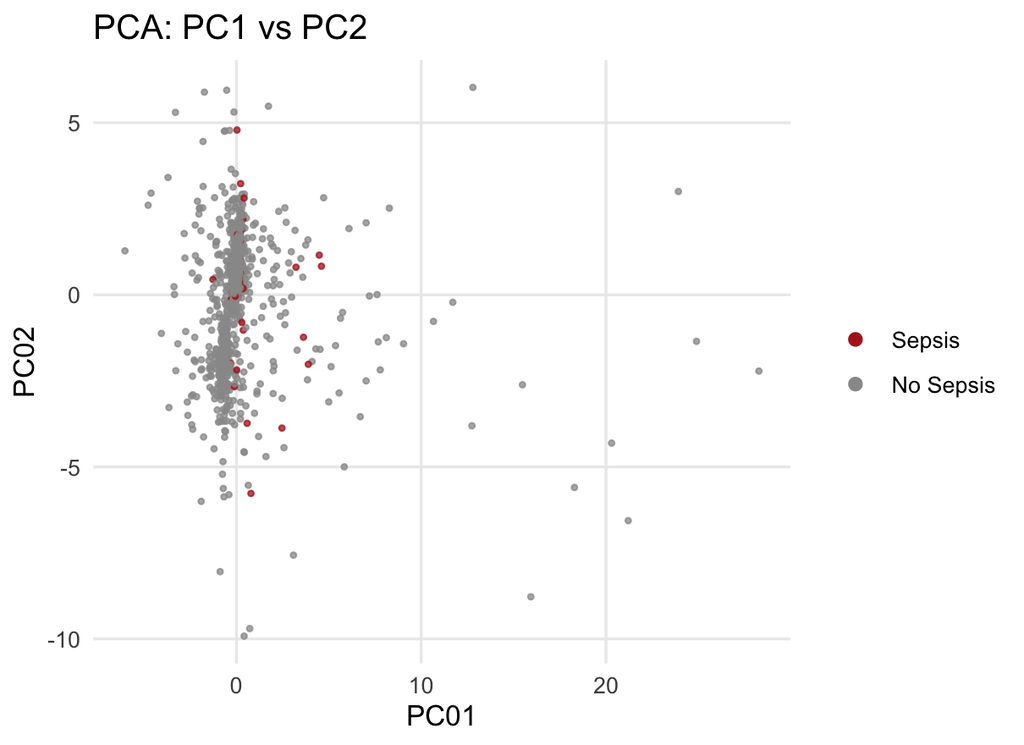

```r
pca_scores |>
  ggplot(aes(PC01, PC02, colour = SepsisLabel)) +
  geom_point(alpha = 0.75, size = 0.7) +
  scale_colour_manual(values = c("No Sepsis" = "grey60",
                                 "Sepsis"    = "firebrick")) +
  labs(title = "PCA: PC1 vs PC2", colour = NULL) +
  guides(colour = guide_legend(override.aes = list(alpha = 1, size = 2)))
```

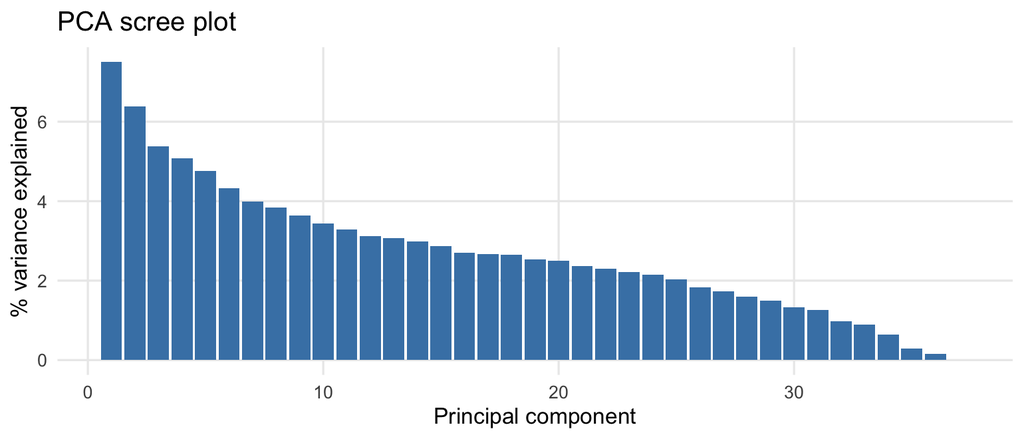

```r
tidy(pca_prep, id = "pca", type = "variance") |>
  filter(terms == "percent variance") |>
  ggplot(aes(component, value)) +
  geom_col(fill = "steelblue") +
  labs(x = "Principal component", y = "% variance explained",
       title = "PCA scree plot")
```

The two classes overlap heavily in the PC1/PC2 projection — this is common in clinical data where no single linear combination cleanly separates cases.

**Q10 (2 marks).** What does this tell us about the potential decision boundary our predictive model would have to fit? Which models easily support this type of boundary?

- The classes are not linearly separable — the Sepsis points (red) sit entirely within the No-Sepsis cloud in PC1 vs PC2. There is no margin or gap a hyperplane could exploit. Any linear boundary would cut through both classes indiscriminately. This suggests that the decision boundary would need to be non-linear to effectively separate the classes. Models like decision trees, random forests, and neural networks are well-suited for capturing such complex, non-linear boundaries.

## 4 Feature Engineering

Let’s create a few new features likely to be informative for sepsis:

**Q11. (1 mark)** Modify the following code to also add an additional feature called `shock_index` which is defined as heart rate divided by the systolic blood pressure.

```r
add_features <- function(df) {
  df |>
    mutate(
      pulse_pressure  = SBP - DBP,
      bun_creat_ratio = BUN / Creatinine,  # > 20 suggests pre-renal AKI
      shock_index = HR/SBP, #implemented shock index
      age_group = cut(Age,
                      breaks = c(-1, 40, 65, 80, 120),
                      labels = c("<=40", "41-65", "66-80", "80+"))
    )
}
train <- add_features(train)
test  <- add_features(test)
```

## 5 Modelling

Now lets try to fit some predictive models to the training set

### 5.1 Cross-validation folds

Five-fold stratified CV on the training set, used to select hyperparameters (see below) by repeatedly training the model with different hyperparameter values on 4/5ths of the data and evaluating on each of the held-out 1/5ths.s

```r
folds <- vfold_cv(train, v = 5, strata = SepsisLabel)
```

### 5.2 Preprocessing recipes

Not all models can handle the same type of data and some models (like linear models) benefit from normalising values to similar ranges. Most models will ignore missing values but we are going to add a missingness-indicator columns so the model can learn from *which* values are absent.

We are going to use `tidymodel` recipes again so we can apply the training normalisation etc to the test set to prevent leakage.

```r
base_recipe <- recipe(SepsisLabel ~ ., data = train) |>
  step_rm(ICULOS, HospAdmTime) |>
  step_indicate_na(all_numeric_predictors(), prefix = "miss") |>
  step_impute_median(all_numeric_predictors()) |>
  step_impute_mode(all_nominal_predictors()) |>
  step_novel(all_nominal_predictors()) |>
  step_dummy(all_nominal_predictors(), one_hot = FALSE) |>
  step_zv(all_predictors())

glm_recipe <- base_recipe |>
  step_normalize(all_numeric_predictors())
```

### 5.3 Model specifications

Now let’s specify our 3 models: - Logistic regression: a linear baseline. Outputs P(Sepsis∣X) via a logistic link function (i.e., squeezing our linear model through a sigmoid function that constrains between 0 and 1). By default `glmnet` uses a regularised model. This means we are penalising the model complexity (the size of the weights/coefficients are added to the cost function). Specifically, we are using an cross-validation optimied combination of L1 and L2 penalties (absolute and squared weight/coefficient sizes). This is useful as many of our ~40 lab variables are correlated or weakly informative.

- Random forest: an ensemble of decision trees, each fit on a bootstrap sample with a random subset of features at each split. Captures non-linearities and interactions automatically, and handles mixed-scale features without preprocessing. Robust to outliers and (via `ranger`) to NAs.
- XGBoost: gradient-boosted trees. Builds trees sequentially, each one correcting the residual errors of the previous ensemble. Typically the strongest tabular performer, but the most sensitive to model (hyper)parameters and easy to overfit without tuning.

Each of these has several hyperparameters (parts of the model we don’t directly learn from the data during fitting; instead we choose them before fitting and select the best values by cross-validation). Marking a hyperparameter with `tune()` is a placeholder that says “leave this blank for now — we’ll fill it in during the tuning step.” The values will later be chosen by tune_grid() based on cross-validated performance on the training folds.

**Q12 4 marks**: Using R’s documentation (e.g., `?logistic_reg`) look up and briefly explain each of the hyperparamters we are tuning in cross-validation for each of the 3 models:s

```r
glm_spec <- logistic_reg(penalty = tune(), mixture = tune()) |>
  set_engine("glmnet") |>
  set_mode("classification")

# hyperparameters: penalty scaling factor and proportion L1 vs L2s
rf_spec <- rand_forest(trees = 500, min_n = tune()) |>
  set_engine("ranger", importance = "permutation", num.threads = 1) |>
  set_mode("classification")

xgb_spec <- boost_tree(
  trees = 500, tree_depth = tune(), learn_rate = tune(),
  loss_reduction = tune(), sample_size = tune(),
   min_n = tune()
) |>
  set_engine("xgboost", nthread = 1) |>
  set_mode("classification")
```

### 5.4 Tune all three models

Now let’s specify our workflow to use cross-validation to tune all models and compare across them.

```r
wf_set <- workflow_set(
  preproc = list(glm = glm_recipe, rf = base_recipe, xgb = base_recipe),
  models  = list(glm = glm_spec,   rf = rf_spec,      xgb = xgb_spec),
  cross   = FALSE
)
```

We are going to calculate a set of different performance metrics across CV folds.

Now we can run it, this will take a few minutes so we can use cache-ing again to avoid frustration!

```r
cls_metrics <- metric_set(pr_auc, brier_class, accuracy, sensitivity, specificity)

tuned <- wf_set |>
  workflow_map(
    fn        = "tune_grid",
    seed      = GLOBAL_SEED ,
    resamples = folds,
    grid      = 10,
    metrics   = cls_metrics,
    control   = control_grid(save_pred = TRUE, verbose = FALSE)
  )
```

### 5.5 Compare cross-validation results

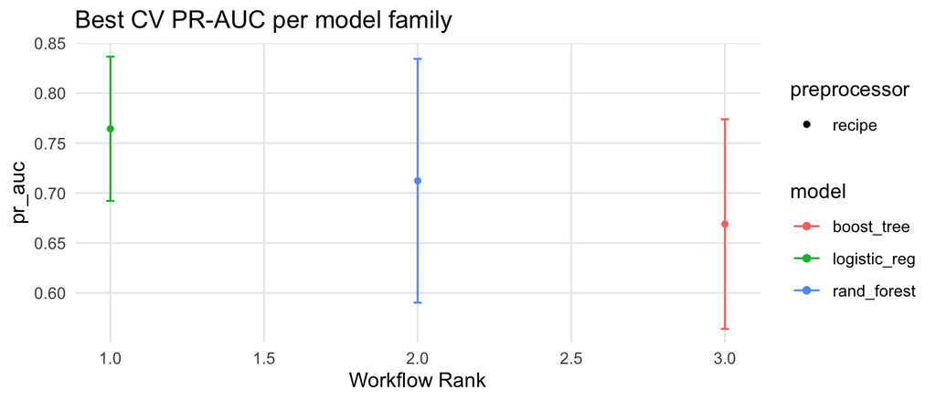

```r
autoplot(tuned, metric = "pr_auc", select_best = TRUE) +
  labs(title = "Best CV PR-AUC per model family")
```

```r
rank_results(tuned, rank_metric = "pr_auc", select_best = TRUE) |>
  filter(.metric %in% c("pr_auc", "brier_class", "accuracy", "sensitivity", "specificity")) |>
  select(wflow_id, .metric, mean, std_err, rank)
```

```
## # A tibble: 15 × 5
##    wflow_id .metric       mean  std_err  rank
##    <chr>    <chr>        <dbl>    <dbl> <int>
##  1 glm_glm  accuracy    0.981  0.00206      1
##  2 glm_glm  brier_class 0.0146 0.00164      1
##  3 glm_glm  pr_auc      0.764  0.0439       1
##  4 glm_glm  sensitivity 0.427  0.0771       1
##  5 glm_glm  specificity 0.999  0.000557     1
##  6 rf_rf    accuracy    0.980  0.00285      2
##  7 rf_rf    brier_class 0.0179 0.00242      2
##  8 rf_rf    pr_auc      0.712  0.0742       2
##  9 rf_rf    sensitivity 0.382  0.0434       2
## 10 rf_rf    specificity 1      0            2
## 11 xgb_xgb  accuracy    0.978  0.00314      3
## 12 xgb_xgb  brier_class 0.0176 0.00212      3
## 13 xgb_xgb  pr_auc      0.669  0.0638       3
## 14 xgb_xgb  sensitivity 0.4    0.0444       3
## 15 xgb_xgb  specificity 0.997  0.00112      3
```

**Q14 (3 marks).** By summarising and comparing the metrics output by this code, describe how each model performed relative to one another.

**- Accuracy is uninformative** across all three = consequence of class imbalance.

**- Logistic regression leads on PR-AUC and Brier score**, meaning it best discriminates sepsis patients and is most well-calibrated in its predicted probabilities.

**- Specificity is near-perfect for all models**, so false alarm rates are not a meaningful differentiator here.

## 6 Test-Set Evaluation

In the real-world we’d try to optimise these models further and/or try some different architectures but lets just take our best model and continue to test evaluation.

### 6.1 Finalise the best model

```r
best_id <- rank_results(tuned, rank_metric = "pr_auc",
                        select_best = TRUE) |>
  filter(.metric == "pr_auc") |>
  slice_head(n = 1) |>
  pull(wflow_id)

final_wf <- extract_workflow(tuned, id = best_id) |>
  finalize_workflow(
    extract_workflow_set_result(tuned, id = best_id) |>
      select_best(metric = "pr_auc")
  )

split <- make_splits(train, test)
final_fit <- last_fit(final_wf, split = split, metrics = cls_metrics)
collect_metrics(final_fit)
```

```
## # A tibble: 5 × 4
##   .metric     .estimator .estimate .config
##   <chr>       <chr>          <dbl> <chr>
## 1 accuracy    binary        0.975  pre0_mod0_post0
## 2 sensitivity binary        0.414  pre0_mod0_post0
## 3 specificity binary        0.997  pre0_mod0_post0
## 4 pr_auc      binary        0.701  pre0_mod0_post0
## 5 brier_class binary        0.0194 pre0_mod0_post0
```

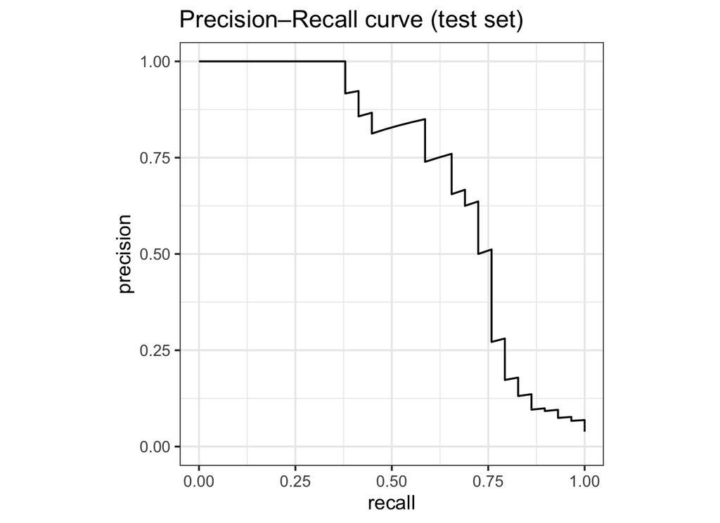

```r
preds <- collect_predictions(final_fit)

preds |>
  pr_curve(truth = SepsisLabel, .pred_Sepsis,
           event_level = "first") |>
  autoplot() + labs(title = "Precision–Recall curve (test set)")
```

### 6.3 Confusion matrix

**Q15 (1 marks).** How many times were true sepsis cases classified as non-sepsis in the test set? Is this more or less than the correct sepsis predictions?

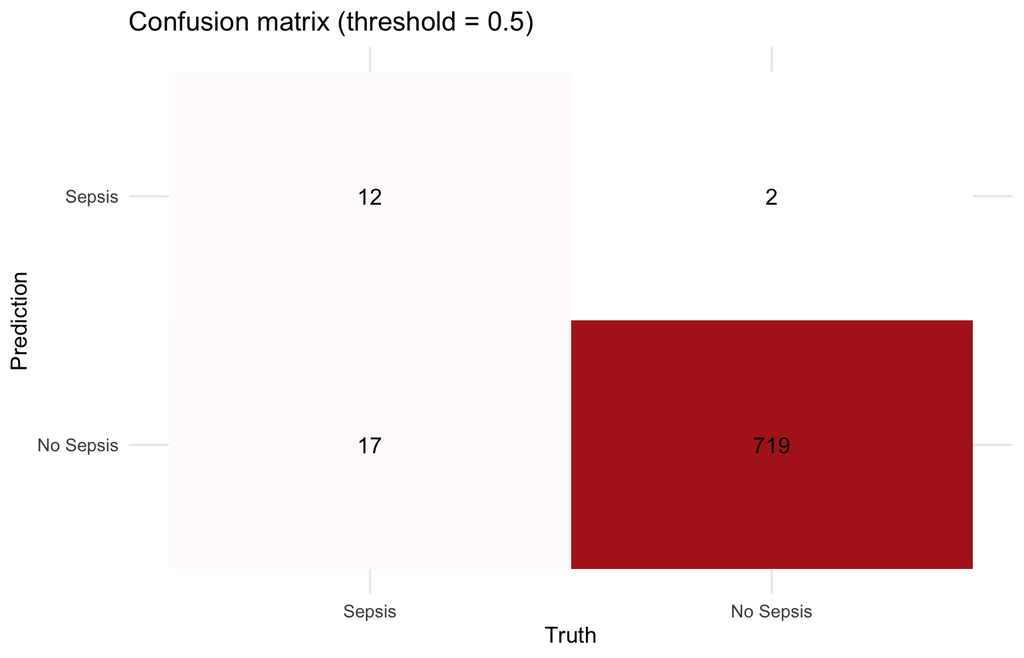

```r
preds |>
  conf_mat(truth = SepsisLabel, estimate = .pred_class) |>
  autoplot(type = "heatmap") +
  scale_fill_gradient(low = "white", high = "firebrick") +
  labs(title = "Confusion matrix (threshold = 0.5)")
```